# HackMIT Education Analysis

Jacqueline Deprey, Joshua Seides, Ethan Zou

September 14, 2019

## Role of Money in the United States Education System

For this project, our team wanted to learn more about data science and the mining and analysis process. Because we are working within the scope of the Education track at HackMIT this year, we decided to examine the role money plays in America’s education system. This insights are important since analysis such as this could affect public policy decisions made by the government as well as how Americans view the current education system and therefore could change which candidate’s educational policy they believe is best for improving our nation which could influence their vote in the upcoming election.

# Description of dataset

“U.S. Education Datasets: Unification Project” is a dataset designed to bring together multiple facets of U.S. education data into one convenient CSV. There are 1492 entities, or objects that the dataset refers to. Each entity represents the educational system in a particular year in a certain state. There are 25 different attributes, including:

| Attribute | Description |
| --- | --- |
| PRIMARY_KEY | A unique identifier for each piece of data |
| STATE | The territory within the United States the data is from |
| YEAR | The year the data is from |
| ENROLL | The U.S. Census Bureau’s count for students in the state. Should be comparable to GRADES_ALL |
| TOTAL_REVENUE | The total amount of money in dollars an individual state’s education system gets in a particular year |
| FEDERAL_REVENUE | The amount of money in dollars an individual state’s education system gets in a particular year from the federal government |
| STATE_REVENUE | The amount of money in dollars an individual state’s education system gets in a particular year from the state government |
| LOCAL_REVENUE | The amount of money in dollars an individual state’s education system gets in a particular year from the local governments that make up that state |
| TOTAL_EXPENDITURE | The total amount of money in dollars an individual state’s education system spends in a particular year |
| INSTRUCTION_EXPENDITURE | The amount of money in dollars an individual state’s education system spends in a particular year on instruction (i.e. teachers and online resources that directly help students learn) |
| SUPPORT_SERVICES_EXPENDITURE | The total amount of money in dollars an individual state’s education system spends in a particular year on support services (i.e. materials that help teachers instruct students) |
| OTHER_EXPENDITURE | The total amount of money in dollars an individual state’s education system spends in a particular year on other expenses. |
| CAPITAL_OUTLAY_EXPENDITURE | The total amount of money in dollars an individual state’s education system spends in a particular year on fixed assets and/or extending the useful lives of the equipment the state alreaday has. |
| GRADES_PK_G | The number of students in pre-school/early childhood development programs |
| GRADES_KG_G | The number of students in kindergarden |
| GRADES_4_G | The number of students in 4th grade |
| GRADES_8_G | The number of students in 8th grade |
| GRADES_12_G | The number of students in 12th grade |
| GRADES_1_8_G | The number of students in grades 1-8 inclusive |
| GRADES_9_12_G | The number of students in grades 9-12 inclusive |
| GRADES_ALL_G | The total number of students in all grades |
| AVG_MATH_4_SCORE | The average math score of a 4th grader |
| AVG_MATH_8_SCORE | The average math score of a 8th grader |
| AVG_READING_4_SCORE | The average reading score of a 4th grader |
| AVG_READING_8_SCORE | The average reading score of a 8th grader |

The dataset was obtained as a CSV file from Kaggle.com. Kaggle is an online community of data scientists, owned by Google LLC. Users find and publish data sets, explore and build models in a data-science environment, work with other data scientists, and enter competitions to solve data science challenges. This specific dataset was uploaded 6 months ago by Roy Garrad. To load this CSV file into an R data frame, which we can then use for analysis, we must use read_csv method() to read in the data and use the as_data_frame() method to transform it into a data frame, as seen below.

```r
dat <- read.csv("C:/Users/jacq_/Documents/Programming/CMSC320/states_all.csv")
as_data_frame(dat)
```

| PRIMARY_KEY | STATE | YEAR | ENROLL | TOTAL_REVENUE | FEDERAL_REVENUE | STATE_REVENUE | LOCAL_REVENUE | TOTAL_EXPENDITURE | INSTRUCTION_EXPENDITURE | SUPPORT_SERVICES_EXPENDITURE | OTHER_EXPENDITURE | CAPITAL_OUTLAY_EXPENDITURE | GRADES_PK_G | GRADES_KG_G | GRADES_4_G | GRADES_8_G | GRADES_12_G | GRADES_1_8_G | GRADES_9_12_G | GRADES_ALL_G | AVG_MATH_4_SCORE | AVG_MATH_8_SCORE | AVG_READING_4_SCORE | AVG_READING_8_SCORE |
| --- | --- | --- | --- | --- | --- | --- | --- | --- | --- | --- | --- | --- | --- | --- | --- | --- | --- | --- | --- | --- | --- | --- | --- | --- |
| 1992_ALABAMA | ALABAMA | 1992 | NA | 2678885 | 304177 | 1659028 | 715680 | 2653798 | 1481703 | 735036 | NA | 174053 | 8224 | 55460 | 57948 | 58025 | 41167 | 471564 | 196386 | 676174 | 208.3279 | 252.1875 | 207.9635 | NA |
| 1992_ALASKA | ALASKA | 1992 | NA | 1049591 | 106780 | 720711 | 222100 | 972488 | 498362 | 350902 | NA | 37451 | 2371 | 10152 | 9748 | 8789 | 6714 | 79117 | 30847 | 112335 | NA | NA | NA | 258.8597 |
| 1992_ARIZONA | ARIZONA | 1992 | NA | 3258079 | 297888 | 1369815 | 1590376 | 3401580 | 1435908 | 1007732 | NA | 609114 | 2544 | 53497 | 55433 | 49081 | 37410 | 437127 | 175210 | 614881 | 215.2539 | 265.3663 | 206.2127 | 262.1699 |
| 1992_ARKANSAS | ARKANSAS | 1992 | NA | 1711959 | 178571 | 958785 | 574603 | 1743022 | 964323 | 483488 | NA | 145212 | 808 | 33511 | 34632 | 36011 | 27651 | 281338 | 123113 | 405259 | 210.2060 | 256.3121 | 208.6345 | 264.6197 |
| 1992_CALIFORNIA | CALIFORNIA | 1992 | NA | 26260025 | 2072470 | 16546514 | 7641041 | 27138832 | 14358922 | 8520926 | NA | 2044688 | 59067 | 431763 | 418418 | 363296 | 270675 | 3286034 | 1372011 | 4717112 | 208.3990 | 260.8922 | 196.7644 | NA |
| 1992_COLORADO | COLORADO | 1992 | NA | 3185173 | 163253 | 1307986 | 1713934 | 3264826 | 1642466 | 1035970 | NA | 364760 | 7410 | 47588 | 50648 | 45025 | 34533 | 394904 | 160299 | 562613 | 221.0234 | 272.3984 | 213.4809 | 266.4197 |
| 1992_CONNECTICUT | CONNECTICUT | 1992 | NA | 3834302 | 143542 | 1342539 | 2348221 | 3721338 | 2148041 | 1142600 | NA | 48542 | 5731 | 41319 | 38058 | 33691 | 28366 | 304284 | 126917 | 436932 | 226.7985 | 273.7393 | 222.4176 | 264.7139 |
| 1992_DELAWARE | DELAWARE | 1992 | NA | 645233 | 45945 | 420942 | 178346 | 638784 | 372722 | 194915 | NA | 30595 | 463 | 8025 | 8272 | 8012 | 6129 | 67495 | 28338 | 96296 | 217.9000 | 262.8686 | 206.3891 | 261.5779 |
| 1992_DISTRICT_OF_COLUMBIA | DISTRICT_OF_COLUMBIA | 1992 | NA | 709480 | 64749 | 0 | 644731 | 742893 | 329160 | 316679 | NA | 47272 | 4818 | 6667 | 5832 | 5000 | 3433 | 47009 | 18173 | 70000 | 192.6006 | 234.9246 | 178.5576 | 265.9768 |
| 1992_FLORIDA | FLORIDA | 1992 | NA | 11506299 | 788420 | 5683949 | 5033930 | 11305642 | 5166374 | 3410440 | NA | 1667826 | 31464 | 161701 | 164416 | 142372 | 100835 | 1276685 | 511557 | 1819706 | 213.6898 | 259.9088 | 204.8826 | 262.1190 |

[output cut: 1482 more lines]

# Tidying the Dataset

It is important that before we analyze our data, it is presented in such a manner that it is responsive to analysis, in both modeling and visualization. To do this, we have structured our data according to the Entity-Relationship model. This is a data structure where each attribute forms a column, each entity forms a row, and each type of entity forms a table. Once our data is presented as such, we modified some of the entities to make it easier to analyze. To do this, we dropped all of the “NAs” in the data frame, as they wouldn’t be useful to our analysis.

```r
dat <- dat %>%
  drop_na()


head(as_data_frame(dat))
```

| PRIMARY_KEY | STATE | YEAR | ENROLL | TOTAL_REVENUE | FEDERAL_REVENUE | STATE_REVENUE | LOCAL_REVENUE | TOTAL_EXPENDITURE | INSTRUCTION_EXPENDITURE | SUPPORT_SERVICES_EXPENDITURE | OTHER_EXPENDITURE | CAPITAL_OUTLAY_EXPENDITURE | GRADES_PK_G | GRADES_KG_G | GRADES_4_G | GRADES_8_G | GRADES_12_G | GRADES_1_8_G | GRADES_9_12_G | GRADES_ALL_G | AVG_MATH_4_SCORE | AVG_MATH_8_SCORE | AVG_READING_4_SCORE | AVG_READING_8_SCORE |
| --- | --- | --- | --- | --- | --- | --- | --- | --- | --- | --- | --- | --- | --- | --- | --- | --- | --- | --- | --- | --- | --- | --- | --- | --- |
| 1996_ALABAMA | ALABAMA | 1996 | 735912 | 3365113 | 334858 | 2138717 | 891538 | 3572283 | 1987018 | 935115 | 322883 | 286699 | 9633 | 60949 | 57098 | 58305 | 42510 | 469370 | 207980 | 686983 | 211.6470 | 256.5949 | 210.9208 | 260.2764 |
| 1996_ARIZONA | ARIZONA | 1996 | 764681 | 4143304 | 378917 | 1798363 | 1966024 | 4391555 | 1860007 | 1193260 | 220650 | 877190 | 4495 | 64613 | 62793 | 60514 | 42041 | 511925 | 210289 | 726709 | 217.5759 | 267.8748 | 206.5298 | 263.2836 |
| 1996_ARKANSAS | ARKANSAS | 1996 | 452907 | 2183384 | 192152 | 1296247 | 694985 | 2297381 | 1264275 | 636106 | 127007 | 203555 | 1980 | 36442 | 33855 | 37064 | 27613 | 283883 | 131997 | 417860 | 215.8464 | 261.6527 | 208.8377 | 271.8346 |
| 1996_CALIFORNIA | CALIFORNIA | 1996 | 5460484 | 31282981 | 2603882 | 17061474 | 11617625 | 31561692 | 16880730 | 9222569 | 2362407 | 2580639 | 73233 | 469965 | 435217 | 406456 | 298669 | 3516572 | 1525618 | 5115423 | 209.1291 | 262.7725 | 201.9126 | 269.1975 |
| 1996_COLORADO | COLORADO | 1996 | 655679 | 3891203 | 194998 | 1664676 | 2031529 | 4075165 | 2052264 | 1127563 | 143767 | 588209 | 12520 | 50707 | 52524 | 52269 | 37179 | 423510 | 185700 | 621730 | 225.8059 | 275.6082 | 221.6532 | 268.1682 |
| 1996_CONNECTICUT | CONNECTICUT | 1996 | 499815 | 4686025 | 162218 | 1703171 | 2820636 | 4538234 | 2701637 | 1296119 | 149792 | 149327 | 9147 | 43213 | 41969 | 37991 | 28882 | 335296 | 137753 | 482196 | 232.0266 | 279.5912 | 231.5983 | 263.6898 |

# General Data Visualization / Analysis

Data Visualization is a very important aspect of data science. It allows us to gain understanding of dataset characteristics throughout our analysis, and helps us easily communicate discovered insights derived from said analysis. To start off our analysis, we decided to check to see the frequencies of the number of times each state appeared in our dataset. By visualizing this and taking it into acount early, we can begin to see is our data might potentially be skewed if some states have a lower frequency than others thereby giving each value more influence over that state’s summary statistics.

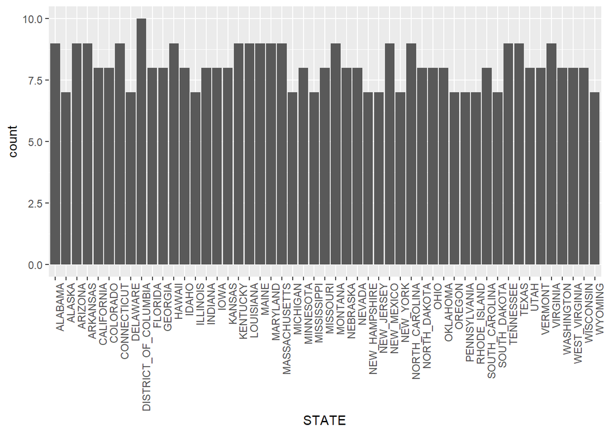

```r
dat %>%
  ggplot(mapping=aes(x=STATE)) +
    geom_bar() + theme(axis.text.x=element_text(angle=90, hjust=1))
```

First, we decided to collect summary statistics on our data.

```r
summary(dat)
```

```
##                     PRIMARY_KEY                   STATE          YEAR
##  2009_DISTRICT_OF_COLUMBIA:  2   DISTRICT_OF_COLUMBIA: 10   Min.   :1996
##  1996_ALABAMA             :  1   ALABAMA             :  9   1st Qu.:2003
##  1996_ARIZONA             :  1   ARIZONA             :  9   Median :2007
##  1996_ARKANSAS            :  1   ARKANSAS            :  9   Mean   :2008
##  1996_CALIFORNIA          :  1   CONNECTICUT         :  9   3rd Qu.:2011
##  1996_COLORADO            :  1   HAWAII              :  9   Max.   :2015
##  (Other)                  :406   (Other)             :358
##      ENROLL        TOTAL_REVENUE      FEDERAL_REVENUE   STATE_REVENUE
##  Min.   :  44179   Min.   :  678874   Min.   :  57870   Min.   :       0
##  1st Qu.: 279456   1st Qu.: 2654366   1st Qu.: 259390   1st Qu.: 1431621
##  Median : 665109   Median : 6029807   Median : 535223   Median : 2962151
##  Mean   : 931623   Mean   :10344944   Mean   : 930181   Mean   : 4773503
##  3rd Qu.:1014577   3rd Qu.:11905941   3rd Qu.:1014556   3rd Qu.: 5970302
##  Max.   :6307022   Max.   :73958896   Max.   :9990221   Max.   :42333637
##
##  LOCAL_REVENUE      TOTAL_EXPENDITURE  INSTRUCTION_EXPENDITURE
##  Min.   :   28531   Min.   :  703245   Min.   :  318260
##  1st Qu.:  941683   1st Qu.: 2623966   1st Qu.: 1402305
##  Median : 2342892   Median : 6175724   Median : 3166208
##  Mean   : 4641260   Mean   :10452280   Mean   : 5406896
##  3rd Qu.: 5233700   3rd Qu.:11462062   3rd Qu.: 6006275
##  Max.   :34941513   Max.   :74766086   Max.   :41954260
##
##  SUPPORT_SERVICES_EXPENDITURE OTHER_EXPENDITURE CAPITAL_OUTLAY_EXPENDITURE
##  Min.   :  204117             Min.   :  23107   Min.   :   15452
##  1st Qu.:  804253             1st Qu.: 127968   1st Qu.:  236616
##  Median : 1856055             Median : 323913   Median :  593354
##  Mean   : 3051818             Mean   : 473183   Mean   : 1025166
##  3rd Qu.: 3551036             3rd Qu.: 546926   3rd Qu.: 1034539
##  Max.   :21693675             Max.   :3759373   Max.   :10223657
##
##   GRADES_PK_G      GRADES_KG_G       GRADES_4_G       GRADES_8_G
##  Min.   :    91   Min.   :  4528   Min.   :  3423   Min.   :  2860
##  1st Qu.:  3464   1st Qu.: 20988   1st Qu.: 20480   1st Qu.: 20834
##  Median : 12487   Median : 51276   Median : 50899   Median : 50186
##  Mean   : 22196   Mean   : 70967   Mean   : 71372   Mean   : 72044
##  3rd Qu.: 28116   3rd Qu.: 79396   3rd Qu.: 79078   3rd Qu.: 80850
##  Max.   :249524   Max.   :506831   Max.   :493415   Max.   :500143
##
##   GRADES_12_G      GRADES_1_8_G     GRADES_9_12_G      GRADES_ALL_G
##  Min.   :  2188   Min.   :  26762   Min.   :   9970   Min.   :  36823
##  1st Qu.: 18519   1st Qu.: 166618   1st Qu.:  81809   1st Qu.: 259417
##  Median : 41118   Median : 405817   Median : 186662   Median : 624979
##  Mean   : 63247   Mean   : 575617   Mean   : 282127   Mean   : 879940
##  3rd Qu.: 74749   3rd Qu.: 638447   3rd Qu.: 321313   3rd Qu.: 968731
##  Max.   :498403   Max.   :3929869   Max.   :2011865   Max.   :5926631
##
##  AVG_MATH_4_SCORE AVG_MATH_8_SCORE AVG_READING_4_SCORE AVG_READING_8_SCORE
##  Min.   :187.1    Min.   :232.8    Min.   :181.6       Min.   :236.4
##  1st Qu.:232.0    1st Qu.:274.3    1st Qu.:214.9       1st Qu.:259.4
##  Median :238.3    Median :281.4    Median :220.8       Median :265.1
##  Mean   :236.6    Mean   :279.5    Mean   :219.3       Mean   :263.6
##  3rd Qu.:242.7    3rd Qu.:286.1    3rd Qu.:224.5       3rd Qu.:268.2
##  Max.   :253.4    Max.   :300.6    Max.   :236.8       Max.   :277.2
##
```

We then wanted to determine if there was a relationship between the amount of money that was allocated to education and the year. To do this we began plotting our data to see if a visual representation existed.

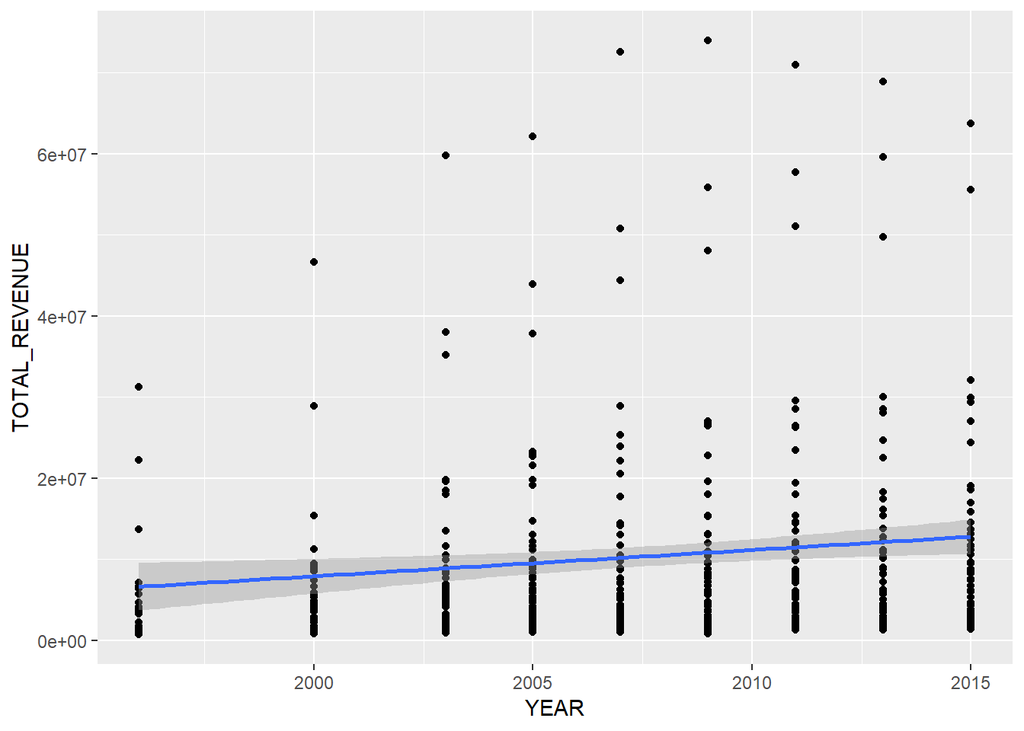

```r
dat %>% ggplot(aes(x = YEAR, y = TOTAL_REVENUE)) + geom_point() + geom_smooth(method=lm)
```

Because they amount of money does seem to increase on average from a visual standpoint each year, we began to do a regression analysis t better determine what that relationship is.

```r
linear_regression <- lm(YEAR ~ TOTAL_REVENUE, data = dat)

linear_regression %>%
  broom::tidy()
```

| term | estimate | std.error | statistic | p.value |
| --- | --- | --- | --- | --- |
| (Intercept) | 2.006930e+03 | 3.310111e-01 | 6063.030255 | 0.000000000 |
| TOTAL_REVENUE | 5.565704e-08 | 2.024369e-08 | 2.749352 | 0.006234743 |

```r
log_regression_revenue <- lm(YEAR ~ log(TOTAL_REVENUE), data = dat)

log_regression_revenue %>%
  broom::tidy()
```

| term | estimate | std.error | statistic | p.value |
| --- | --- | --- | --- | --- |
| (Intercept) | 1994.0180014 | 3.8648510 | 515.936578 | 0.0000000000 |
| log(TOTAL_REVENUE) | 0.8639761 | 0.2470236 | 3.497545 | 0.0005207975 |

```r
log_regression_both <- lm(log(YEAR) ~ log(TOTAL_REVENUE), data = dat)

log_regression_both %>%
  broom::tidy()
```

| term | estimate | std.error | statistic | p.value |
| --- | --- | --- | --- | --- |
| (Intercept) | 7.5979209653 | 0.0019261879 | 3944.537811 | 0.0000000000 |
| log(TOTAL_REVENUE) | 0.0004307105 | 0.0001231131 | 3.498494 | 0.0005190014 |

```r
log_regression_year <- lm(log(YEAR) ~ TOTAL_REVENUE, data = dat)

log_regression_year %>%
  broom::tidy()
```

| term | estimate | std.error | statistic | p.value |
| --- | --- | --- | --- | --- |
| (Intercept) | 7.604358e+00 | 1.649713e-04 | 46095.031438 | 0.000000000 |
| TOTAL_REVENUE | 2.775076e-11 | 1.008918e-11 | 2.750548 | 0.006212446 |

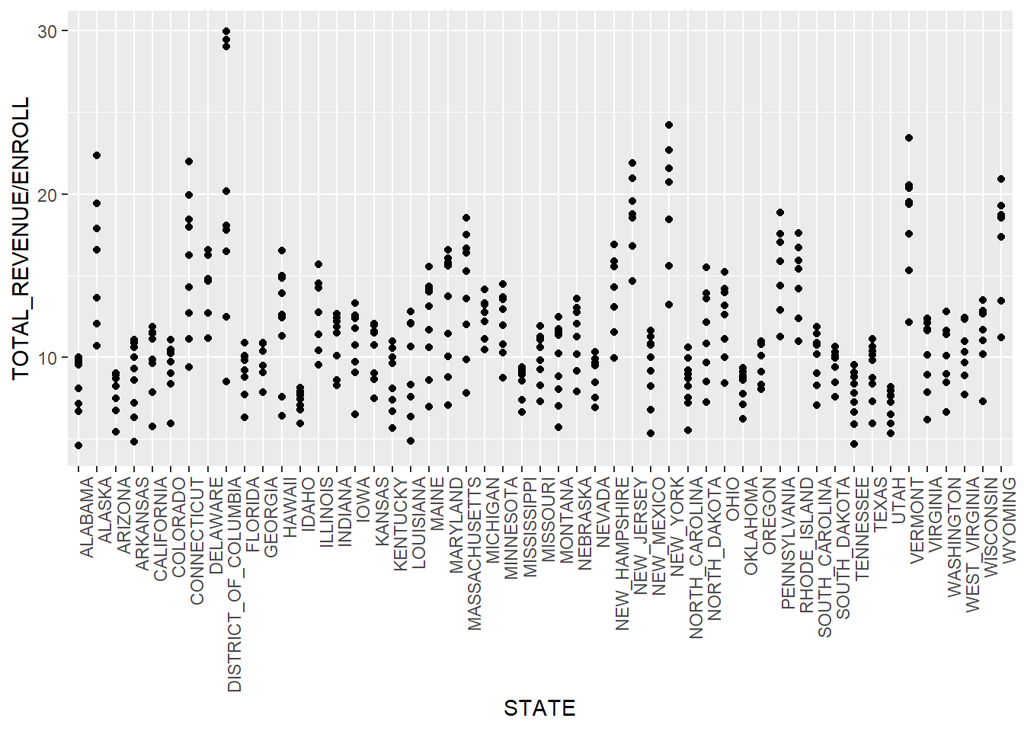

```r
dat %>% ggplot(aes(x = STATE, y = TOTAL_REVENUE/ENROLL)) + geom_point() + theme(axis.text.x=element_text(angle=90, hjust=1))
```

# Conclusion

Aside from the insights we found from our data, we were able to learn a lot more about Data Science by doing this project for HackMIT this year. Not only was our team able to learn a new programming language, R, but we also learned more about this growing field and whether or not we see ourselves exploring opportunities in it down the line.

This project showed us that the logic of R is very similar to that of other programming languages we have dealt with in the past but syntactically very different. We had many frustrations with understanding the syntax of the commands and the format variables needed to be passed in to methods to output our desired result. Although learning R was fun and built our skills as data scientists since R is very prevalent in the field, we believe that we could have achieved the same results in Python in a fraction of the time that it took us to complete this project.

Ultimately, we want to thank the organizers of HackMIT to allow our group to come together and learn new skills together and allow us to examine something that has affected each of us individually: the U.S. Education system. Because all members of our team are from different states (Jacqueline from Maryland, Joshua from Georgia, and Ethan from Massachusetts) we were able to learn more about how funding works for our own school systems but the role it also plays into general statistics as a whole. Through our participation in the education track here we were able to not only learn more ourselves, but also produce some meaningful analysis on the education system as a whole!